# Scale dependendence of SIF

D. Emin

## Summary

> - The distribution of SIF values does not depend on the size of the field
> - SIF ~ LAI relationship is scale dependent in the lower resolutions and scale independent at higher resolutions

## Scale

Choosing the appropriate scale at which to study a particular phenomenon is important. The shape or the strenght of a relationship beteween two environmental variables might differ when observed at two different scales. In this respect, in geography, the term operational scale defines the scale at which a particular spatially continuos phenomenon is most relevant or most promenon. The cartographic scale (coloqualy - the spatial resolution) of a particular research should be governed by the scale at which the phenomenon of interest ist most relevant (e.g. should be chosen to patch as close as possible the operational scale).

Identifying the scale of relevance (the appropraite operational scale) can be done empirically by comparing some goodness-of-fit statistics across the possible scales. For example, we know that LAI, Cab, and LAD are the main drivers of canopy SIF (as modeled by SCOPE) for one individual plant (e.g. the geographic scale is the individual plant). On the other hand, we are interested in the relationship between SIF and canopy structure at larger scales. what happens when we consider the relationship one scale up? What is the most relevant scale to study the relationship from a remote sensing stand point?

Then the agricultural field becomes the boundary and the plant (or the individual pixel) is the elementary unit.

To answer these questions we want to study the SIF-LAI relationship across range of spatial scales. More specifically, we will answer how does the correlation coeficient of the relationship change with scale. Similarly, we will also calculate how does the goodness-of-fit of a linear model change with scale.

- RQ. What is the influence of field size on the summary statistics of a field, e.g. does field average depend on the field size?
- RQ. What is the influence of scale on the relationship between SIF and LAI?
- RQ. Is there a best scale at which to study specific phenonenon.

## Distribution

First. lets see how the distribution of SIF values inside field changes with the size of the field. The size of the fields does not follow a strict normal distribution, but with a simple square root transformation we can achieve a more clear picture.

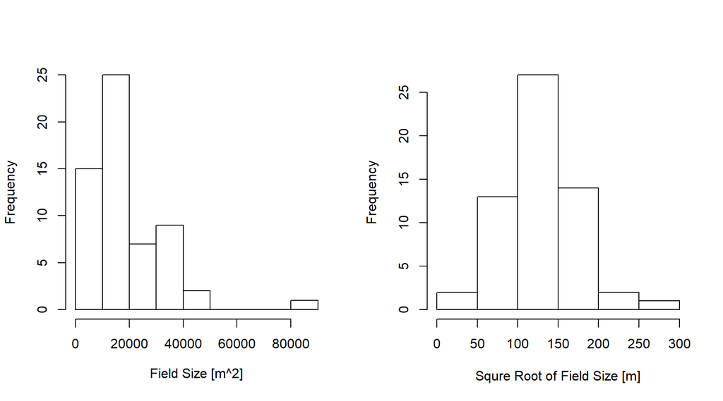

The graphic bellow plots the most important distribution characteristics as a function of field size. What we see is that there is no significant effect of field size on the the distribution of SIF values itself. Most importantly, the standard deviation (in other words the variability) of SIF is scale invariant.

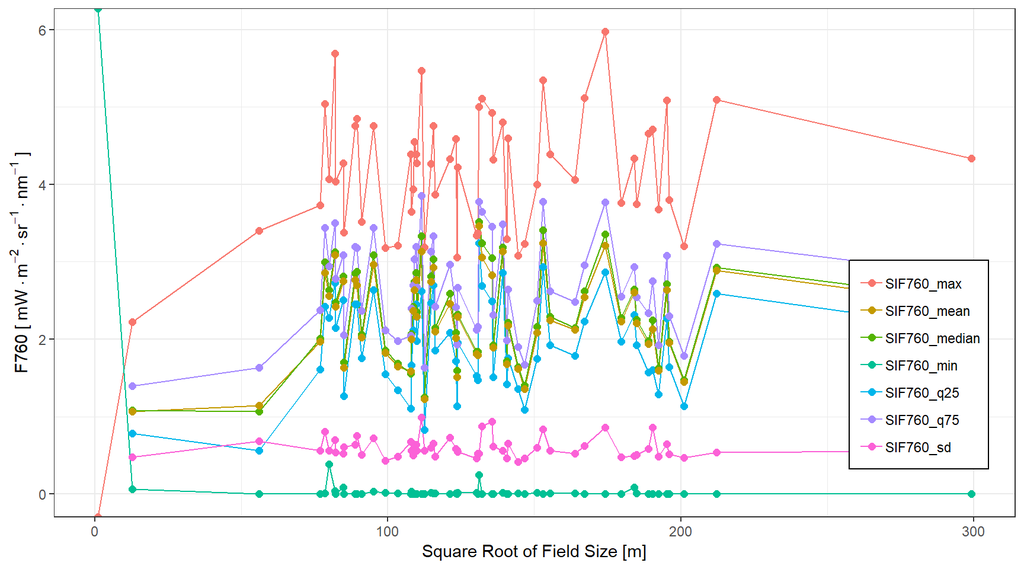

## Scale dependence of SIF - canopy structure. scaling up from pixel to field

Bellow is a graph depicting the sensitivity of SIF ~ LAI relationship based on the cartographic scale (resolution) of input data. HyPlant data was degraded using average pixel statistic. Starting from the nominal 1 meter pixel resolution of HyPlant image, data was degraded by step 2 (e.g to 3, 5, 7, ..,, 99 meter resolution), after which aggregation steps were increased to 10 meter until 300 meter resolution was reached (e.g. 99, 109, 119, …, 309).

The assiciation between SIF760 and LAI remains twice as high as compared to the other two pairs (SIF687 and SIF ration vs. LAI, respectively). From the latter two pairs, SIF ratio ~ LAI outperform slightly SIF687 ~ LAI, particularly in mid-resolution range. Most importantly, a sharp increase of SIF ~ LAI relationship for all three pairs is seen at the inital aggregation range (from 1 to 30 m). The relationships quickly reach an asymthote with R2 statistics remaining relatively constante after approx. 50 meter resolution, although R2 for SIF760 ~ LAI flattens later at larger resolution. In conclusion, SIF ~ LAI becomes scale independent after approx 50 m resolution. The best operational scale for the relationship appears to be between 20 and 50 meter ground sampling resolution.

This has implications for scalability of SIF data and particularly could aid efforts to design a robust donwscaling mechanism from the middle scale FLEX resolution to the finer scale Sentinel 2 and 3 resolution data.

Notes to the graph and analysis. Since data is masked to include only sugar beet fields and all other areas are coded as NA, at approx 120 meters resolution half of the fields are being represented by only one pixel or less. The match between pixel size and field size implies that increasing the size of the pixel does not come with increase in information content. The analysis is based on an equal sample size for each resolution (500 observations). This equal ammount of degrees of freedom ensures comparabilty of resulting models. The reason for the apparent noisiness towards at resolution between 100 m and maximum resolution (309 m) is the small size of the total ammount of pixels which means that the larger resolutions were sampled with replacement to reach the 500 sample size needed for the linear model.

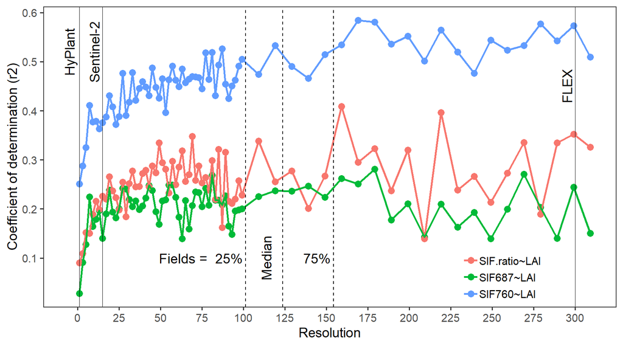